# PML Project

Vasco Pereira

8/22/2020

## Goals

Predict the manner in which the subjects did the exercise, classified as the “classe” variable in the training set. The report describes:  
1 - Exploratory data analysis;  
2 - How the model was built;  
3 - How cross validation was used;  
4 - The expected out of sample error;  
5 - A walkthrough of the made choices.

## Libraries

```r
library(caret)
library(dplyr)
library(ggplot2)
```

## Exploratory Data Analysis

### Download Data

```r
# Download data
training <- read.csv(url("https://d396qusza40orc.cloudfront.net/predmachlearn/pml-training.csv"),
                     header = T)

testing <- read.csv(url("https://d396qusza40orc.cloudfront.net/predmachlearn/pml-testing.csv"),
                     header = T)
```

Dimensions of the original data:  
- training: 19622, 160  
- testing: 20, 160

After downloading the data, it was observed a lot of missing values (it was made by the function `str()`) - not showed here.  
So we will clean the data by removing the missing values by this approach:  
1 - turning missing values into **0**  
2 - removing predictors with *near zero variance*

### Cleaning data

```r
# Turn NA into zero values
training[is.na(training)]<-0
testing[is.na(testing)]<-0 # applying the same transformation to the test set

# Getting near zero variance predictors for training set
nsv_training <- nearZeroVar(training)

# Removing the above predictors from both sets
training_Clean <- (training[,-nsv_training])
testing_Clean <- (testing[,-nsv_training]) # note that all the transformations are made with the training set near zero variance analysis

# Removing predictors that are not useful for the analysis
training_Clean <- training_Clean[,-(1:6)]
testing_Clean <- testing_Clean[,-(1:6)] # applying the same transformation to the test set
```

So both training_Clean and testing_Clean had the same cleaning process and ended with this dimensions:  
- training_Clean: 19622, 53  
- testing_Clean: 20, 53

## Building the model

### Subsetting the train data

To build the model we need our Train set and a Test set with a known outcome in order to access the efficacy of the model. We start by subsetting the data for this purpose.

```r
set.seed(32323)
inTrain <- createDataPartition(y=training_Clean$classe,
                               p=.75,
                               list = F)

trainData <- training_Clean[inTrain, ]
testData <- training_Clean[-inTrain, ]
```

### Creating the model with cross validation

The model was created with Random Forests in order to get greater accuracy, even if the process is a little slower. In order to prevent overfitting, the **train** function was tuned with a **trainControl** function with a 5 fold cross validation resampling method.

```r
set.seed(123)
model <- train(classe ~ ., trainData, method = "rf",
               trControl = trainControl(method = "cv",
                                        number = 5))
print(model)
```

```
## Random Forest
##
## 14718 samples
##    52 predictor
##     5 classes: 'A', 'B', 'C', 'D', 'E'
##
## No pre-processing
## Resampling: Cross-Validated (5 fold)
## Summary of sample sizes: 11775, 11773, 11774, 11774, 11776
## Resampling results across tuning parameters:
##
##   mtry  Accuracy   Kappa
##    2    0.9925940  0.9906315
##   27    0.9924582  0.9904594
##   52    0.9872265  0.9838407
##
## Accuracy was used to select the optimal model using the largest value.
## The final value used for the model was mtry = 2.
```

Since the obtained model have a hight Accuracy: 99.26%, it was used for the predicting in the test data.

## Predicting

Using the **predict()** function we apply the model above to the testData subsetted from the original training set. Then a confusion matrix is made to compare the predicted *classe* with the actual *classe* values.

```r
predictions <- predict(model, testData)

cfMatrix <- confusionMatrix(predictions, testData$classe)
```

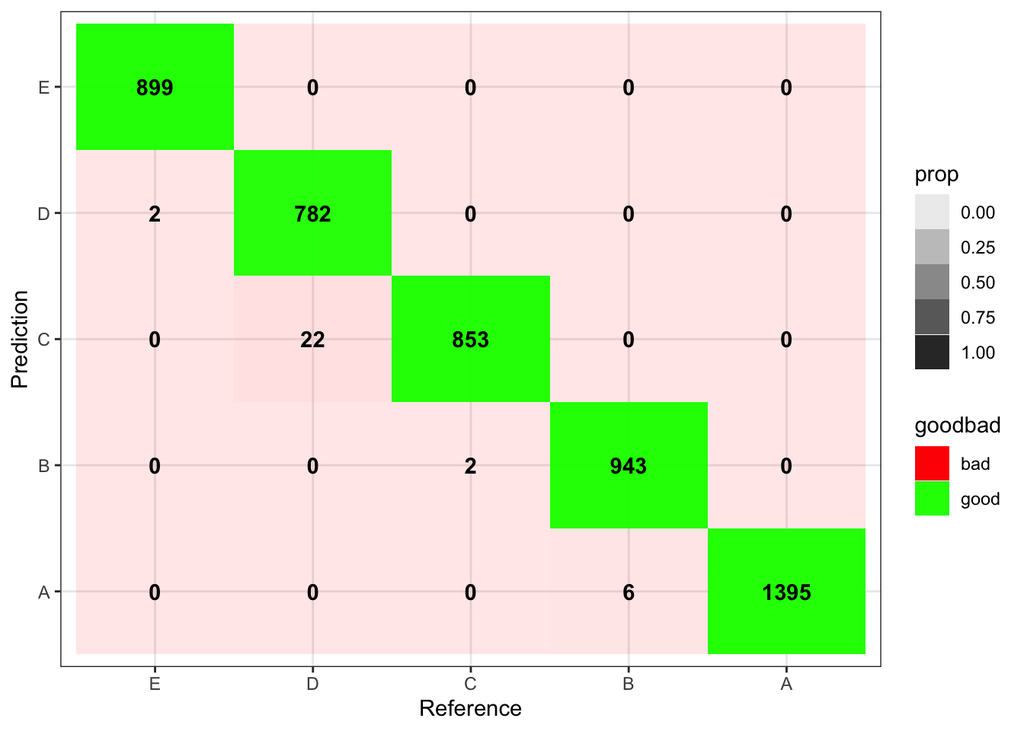

### Accuracy and Out of sample error

The **accuracy** of our model applied to the test data set is 99.35% and the **out of sample error** is 0.65%.

## Predicting for the testing data set

Finally, the model is applied to the testing_Clean to predict the unknown “classe” outcome, not forgetting to remove the `problem_id` from the data frame.

```r
finalResult <- predict(model, testing_Clean[,-53])
print(finalResult)
```

```
##  [1] B A B A A E D B A A B C B A E E A B B B
## Levels: A B C D E
```